# Causal diagrams for the talk

Instrument assumptions, a positive control, survival bias, mediation and the overall model

Author

Dave Bridges

Published

October 30, 2026

Illustrative directed acyclic graphs (DAGs), drawn by hand with `ggplot2` so the layout and colours are fixed. Nothing here is estimated.

**Colour key, used in every diagram:**

| Role | Colour |
| --- | --- |
| Genetic instruments (SNPs) | white, grey outline |
| Exposure (BMI, lean mass) | Michigan maize |
| Mediator (T2D, peak glucose) | Arboretum blue |
| Outcome (AD; T2D in the positive control) | Michigan blue |
| Unmeasured confounding (U) | light grey, dashed outline |
| Selection / survival (lifespan) | Tappan red, square box when conditioned on |

**Arrows:** solid = assumed causal path; dashed grey with a red X = path the instrument assumptions rule out; dotted red = spurious association created by conditioning on a collider (survivor bias); “?” = the effect being estimated.

```r
library(dplyr)
library(tibble)
library(ggplot2)

# ---- palette: edit here ----------------------------------------------------------------------
pal <- list(
  instrument = c(fill = "white",   text = "#00274C", line = "grey45"),
  exposure   = c(fill = "#FFCB05", text = "#00274C", line = "#00274C"),
  mediator   = c(fill = "#2F65A7", text = "white",   line = "#2F65A7"),
  outcome    = c(fill = "#00274C", text = "white",   line = "#00274C"),
  confounder = c(fill = "grey92",  text = "grey30",  line = "grey55"),
  selection  = c(fill = "#9A3324", text = "white",   line = "#9A3324"))
edge_style <- list(
  causal   = list(colour = "#00274C", linetype = "solid",  linewidth = 1.1),
  question = list(colour = "#00274C", linetype = "solid",  linewidth = 1.1),
  blocked  = list(colour = "grey65",  linetype = "dashed", linewidth = 0.9),
  confound = list(colour = "grey55",  linetype = "solid",  linewidth = 0.8),
  induced  = list(colour = "#9A3324", linetype = "dotted", linewidth = 1.1))
# ----------------------------------------------------------------------------------------------

# Nodes: name, label, x, y, role, boxed = conditioned on (drawn with a heavy frame). Box sizes are
# computed from the text and the figure size, so arrows always end at the box edge.
node <- function(name, label, x, y, role, boxed = FALSE, ...) tibble(name, label, x, y, role, boxed)
# Edges: from, to, type (see edge_style), curvature (0 = straight), optional label at the midpoint.
edge <- function(from, to, type = "causal", curvature = 0, label = NA_character_, arrow = TRUE)
  tibble(from, to, type, curvature, label, arrow)

# Half-width / half-height of each node box in data units. Text is drawn at `text_size` mm; a bold
# character is ~0.62 em wide. Data units per inch come from the chunk's fig.width/height and limits.
size_nodes <- function(nodes, xlim, ylim, text_size) {
  fw <- knitr::opts_current$get("fig.width") %||% 9; fh <- knitr::opts_current$get("fig.height") %||% 5
  upi <- max(diff(xlim) / (fw - 0.6), diff(ylim) / (fh - 0.9))      # data units per inch
  em <- text_size * ggplot2::.pt / 72                                 # font size in inches
  lines <- strsplit(nodes$label, "\n", fixed = TRUE)
  nodes |> mutate(w = (purrr::map_int(lines, \(l) max(nchar(l))) * 0.62 * em / 2 + 0.14) * upi,
                  h = (purrr::map_int(lines, length) * 1.05 * em / 2 + 0.11) * upi)
}
`%||%` <- function(a, b) if (is.null(a)) b else a

# Shorten each edge so it starts and ends at the box edges rather than the centres.
trim_edges <- function(nodes, edges, gap) {
  e <- edges |>
    left_join(nodes |> select(from = name, x = x, y = y, w0 = w, h0 = h), by = "from") |>
    left_join(nodes |> select(to = name, xend = x, yend = y, w1 = w, h1 = h), by = "to")
  dx <- e$xend - e$x; dy <- e$yend - e$y
  frac <- function(w, h) pmin(abs(w / dx), abs(h / dy), na.rm = TRUE)
  pad <- gap * (1 + 3 * nodes$boxed[match(c(e$from, e$to), nodes$name)])
  f0 <- frac(e$w0 + pad[seq_len(nrow(e))], e$h0 + pad[seq_len(nrow(e))])
  f1 <- frac(e$w1 + pad[nrow(e) + seq_len(nrow(e))], e$h1 + pad[nrow(e) + seq_len(nrow(e))])
  e <- e |> mutate(x = x + dx * f0, y = y + dy * f0, xend = xend - dx * f1, yend = yend - dy * f1)
  # Label position: the midpoint, pushed sideways for curved edges (positive curvature bends to the
  # right of the direction of travel; the bulge is about curvature/2 of the chord length).
  dx <- e$xend - e$x; dy <- e$yend - e$y
  e |> mutate(mx = (x + xend) / 2 + 0.45 * curvature * dy, my = (y + yend) / 2 - 0.45 * curvature * dx)
}

draw_dag <- function(nodes, edges, title = NULL, caption = NULL, xlim, ylim, text_size = 4.6) {
  nodes <- size_nodes(nodes, xlim, ylim, text_size)
  gap <- 0.04 * max(diff(xlim), diff(ylim)) / 8
  e <- trim_edges(nodes, edges, gap)
  p <- ggplot()
  for (i in seq_len(nrow(e))) {
    s <- edge_style[[e$type[i]]]
    arr <- if (e$arrow[i]) arrow(length = unit(0.22, "inches"), angle = 25, type = "closed") else NULL
    geom <- if (e$curvature[i] == 0) geom_segment else geom_curve
    args <- list(data = e[i, ], mapping = aes(x = x, y = y, xend = xend, yend = yend),
                 colour = s$colour, linetype = s$linetype, linewidth = s$linewidth, arrow = arr)
    if (e$curvature[i] != 0) args$curvature <- e$curvature[i]
    p <- p + do.call(geom, args)
  }
  # Edge annotations after all edges, so they sit on top. Blocked paths get a red "X" drawn as two
  # short strokes (font-independent), beside the label if there is one.
  xr <- 0.1 * max(diff(xlim), diff(ylim)) / 8
  for (i in seq_len(nrow(e))) {
    if (e$type[i] == "blocked") {
      cx <- e$mx[i] - if (is.na(e$label[i])) 0 else (nchar(e$label[i]) * 0.045 + 0.3) * max(diff(xlim), 8) / 8
      p <- p + annotate("segment", x = cx - xr, xend = cx + xr, y = e$my[i] - xr, yend = e$my[i] + xr,
                        colour = "#9A3324", linewidth = 1.6) +
               annotate("segment", x = cx - xr, xend = cx + xr, y = e$my[i] + xr, yend = e$my[i] - xr,
                        colour = "#9A3324", linewidth = 1.6)
    }
    if (!is.na(e$label[i]))
      p <- p + annotate("label", x = e$mx[i], y = e$my[i], label = e$label[i], size = text_size * 0.82,
                        label.size = 0, fill = "white", colour = edge_style[[e$type[i]]]$colour,
                        fontface = "italic")
  }
  nd <- nodes |> mutate(fill = purrr::map_chr(role, \(r) pal[[r]][["fill"]]),
                        line = purrr::map_chr(role, \(r) pal[[r]][["line"]]),
                        text = purrr::map_chr(role, \(r) pal[[r]][["text"]]),
                        lty = if_else(role == "confounder", "dashed", "solid"))
  b <- filter(nd, boxed)
  if (nrow(b)) p <- p + geom_rect(data = b, aes(xmin = x - w - 3 * gap, xmax = x + w + 3 * gap, ymin = y - h - 3 * gap,
                                                ymax = y + h + 3 * gap), fill = "white",
                                  colour = pal$selection[["line"]], linewidth = 1.8)
  p + geom_rect(data = nd, aes(xmin = x - w, xmax = x + w, ymin = y - h, ymax = y + h,
                               fill = I(fill), colour = I(line), linetype = I(lty)), linewidth = 0.9) +
    geom_text(data = nd, aes(x, y, label = label, colour = I(text)), size = text_size, fontface = "bold",
              lineheight = 0.95) +
    coord_equal(xlim = xlim, ylim = ylim, clip = "off") +
    labs(title = title, caption = caption) +
    theme_void(base_size = 15) +
    theme(plot.title = element_text(face = "bold", hjust = 0.5, colour = "#00274C"),
          plot.caption = element_text(hjust = 0.5, colour = "grey30", size = 12),
          plot.margin = margin(10, 20, 10, 20))
}
```

## 0. The problem: confounding in observational data

People with type 2 diabetes have higher rates of AD, but they also differ in age, adiposity, education, socioeconomic position and vascular risk, each of which can affect both conditions. Observational data cannot separate the T2D → AD effect (?) from these common causes (U), and measuring them all is not possible. This is the problem the genetic instrument solves.

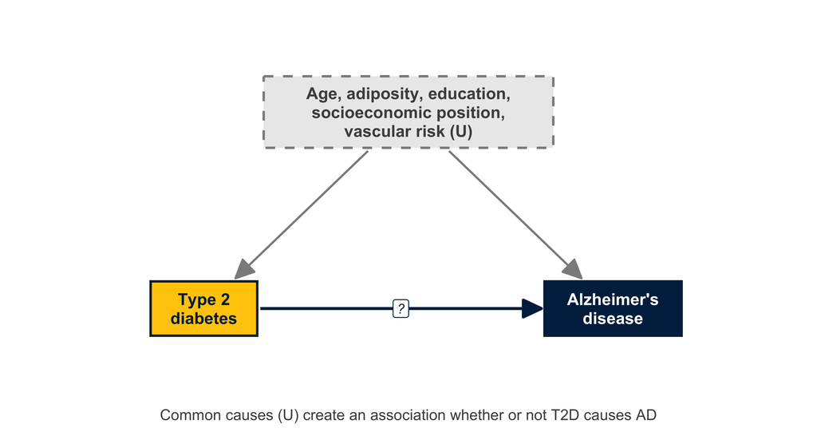

```r
n0 <- bind_rows(
  node("X", "Type 2\ndiabetes", 0, 0, "exposure"),
  node("Y", "Alzheimer's\ndisease", 5, 0, "outcome"),
  node("U", "Age, adiposity, education,\nsocioeconomic position,\nvascular risk (U)", 2.5, 2.4, "confounder"))
e0 <- bind_rows(edge("X", "Y", "question", label = "?"),
                edge("U", "X", "confound"), edge("U", "Y", "confound"))
draw_dag(n0, e0, caption = "Common causes (U) create an association whether or not T2D causes AD",
         xlim = c(-1.3, 6.3), ylim = c(-0.9, 3.4))
```

## 1. The three instrumental-variable assumptions

A genetic variant (G) is a valid instrument for exposure X if (1) it affects X (**relevance**), (2) it shares no cause with the outcome (**independence**: no G–U path), and (3) it affects the outcome only through X (**exclusion restriction**: no direct G → Y path). Unmeasured confounding of X and Y (U) is then irrelevant, because G is allocated at conception independently of U.

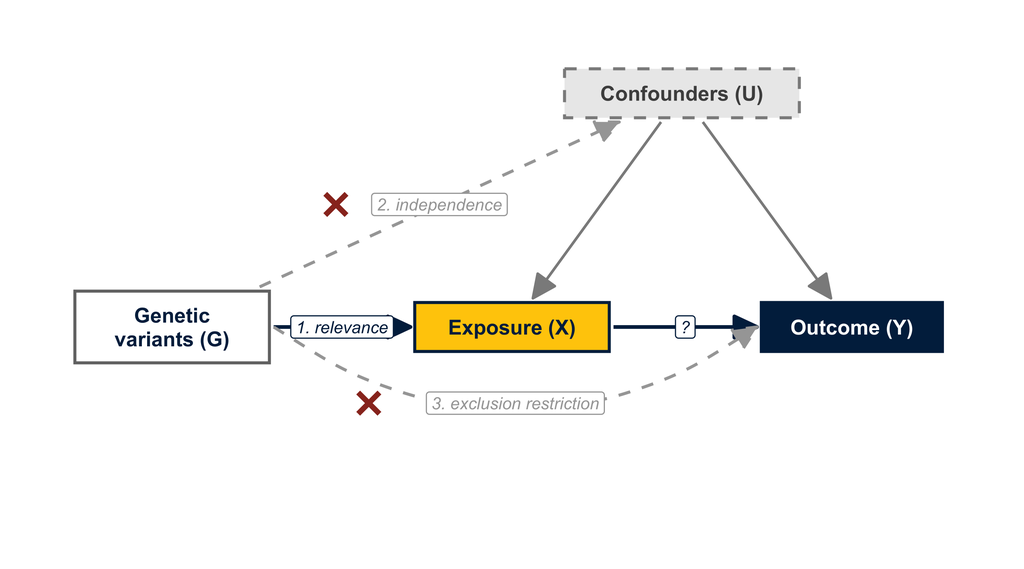

```r
n1 <- bind_rows(
  node("G", "Genetic\nvariants (G)", 0, 0, "instrument", w = 0.8, h = 0.42),
  node("X", "Exposure (X)", 3.2, 0, "exposure", w = 0.85),
  node("Y", "Outcome (Y)", 6.4, 0, "outcome", w = 0.85),
  node("U", "Confounders (U)", 4.8, 2.2, "confounder", w = 0.95))
e1 <- bind_rows(
  edge("G", "X", label = "1. relevance"),
  edge("X", "Y", "question", label = "?"),
  edge("U", "X", "confound"), edge("U", "Y", "confound"),
  edge("G", "U", "blocked", label = "2. independence"),
  edge("G", "Y", "blocked", curvature = 0.35, label = "3. exclusion restriction"))
draw_dag(n1, e1, xlim = c(-0.8, 7.2), ylim = c(-1.9, 2.7))
```

## 2. Positive control: BMI → type 2 diabetes

The same structure with real traits. Diet, activity and socioeconomic position confound BMI and T2D in observational data, but they cannot change the BMI-associated variants a person inherited, so the genetic estimate is not confounded by them as long as the assumptions hold.

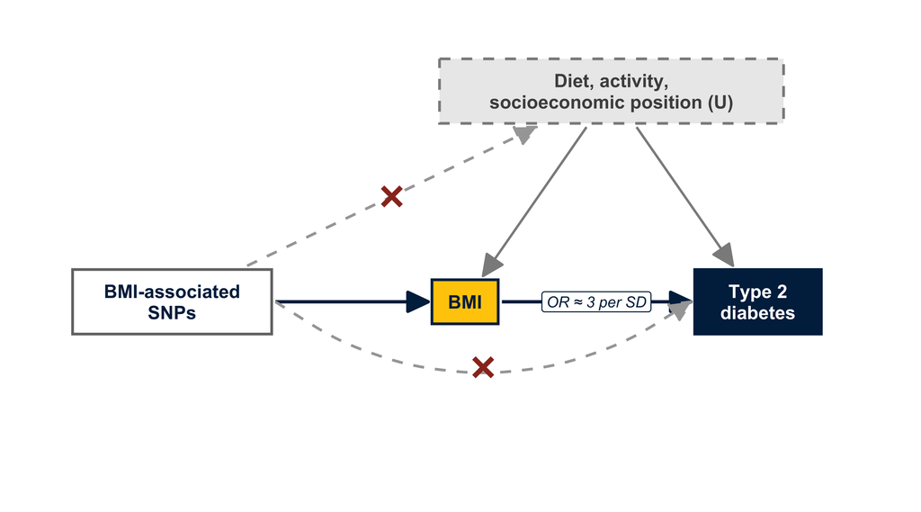

```r
n2 <- bind_rows(
  node("G", "BMI-associated\nSNPs", 0, 0, "instrument", w = 0.85),
  node("X", "BMI", 3.2, 0, "exposure", w = 0.5),
  node("Y", "Type 2\ndiabetes", 6.4, 0, "outcome"),
  node("U", "Diet, activity,\nsocioeconomic position (U)", 4.8, 2.3, "confounder", w = 1.4, h = 0.42))
e2 <- bind_rows(
  edge("G", "X"), edge("X", "Y", "question", label = "OR ≈ 3 per SD"),
  edge("U", "X", "confound"), edge("U", "Y", "confound"),
  edge("G", "U", "blocked"), edge("G", "Y", "blocked", curvature = 0.35))
draw_dag(n2, e2, xlim = c(-0.9, 7.2), ylim = c(-1.9, 2.9))
```

## 3. Survival bias: lifespan as a collider

To be counted as an AD case, a person has to live long enough to develop and be diagnosed with AD. Exposures that shorten life (BMI, T2D) and AD liability both affect survival, so studying survivors conditions on a collider and induces a spurious association between the exposure and AD (dotted red): a life-shortening exposure looks protective. Lean mass barely affects lifespan in our data, so it is the least exposed to this bias.

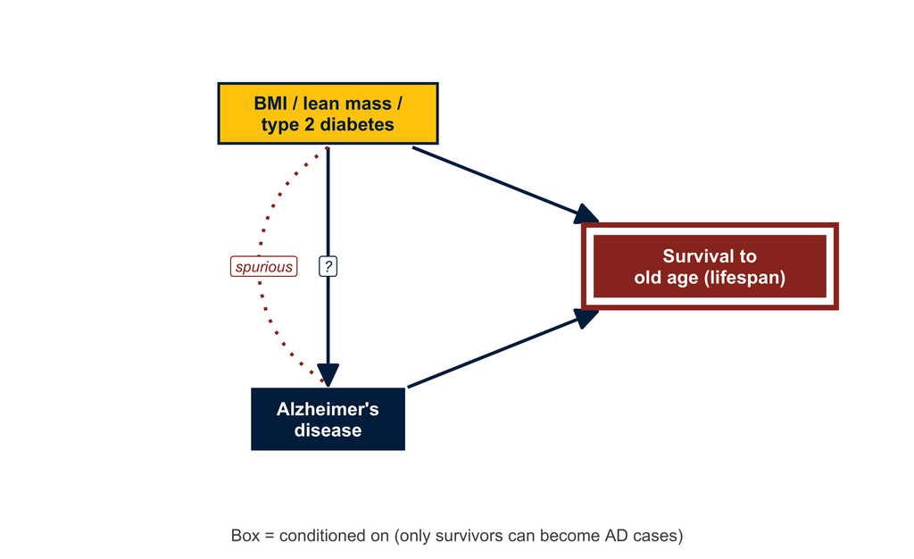

```r
n3 <- bind_rows(
  node("X", "BMI / lean mass /\ntype 2 diabetes", 0, 1.6, "exposure", w = 1.0, h = 0.42),
  node("Y", "Alzheimer's\ndisease", 0, -1.6, "outcome", w = 0.8, h = 0.42),
  node("S", "Survival to\nold age (lifespan)", 4, 0, "selection", w = 1.0, h = 0.42, boxed = TRUE))
e3 <- bind_rows(
  edge("X", "S"), edge("Y", "S"),
  edge("X", "Y", "question", label = "?"),
  edge("X", "Y", "induced", curvature = 0.6, arrow = FALSE, label = "spurious"))
draw_dag(n3, e3, caption = "Box = conditioned on (only survivors can become AD cases)",
         xlim = c(-2.6, 5.3), ylim = c(-2.4, 2.4))
```

## 4. Mediation: lean mass → 2 h glucose → AD

The question is how much of lean mass’s effect on AD runs through 2 h (post-load) glucose (indirect path) versus other routes (direct path). This is the model in `mr_mediation.qmd`.

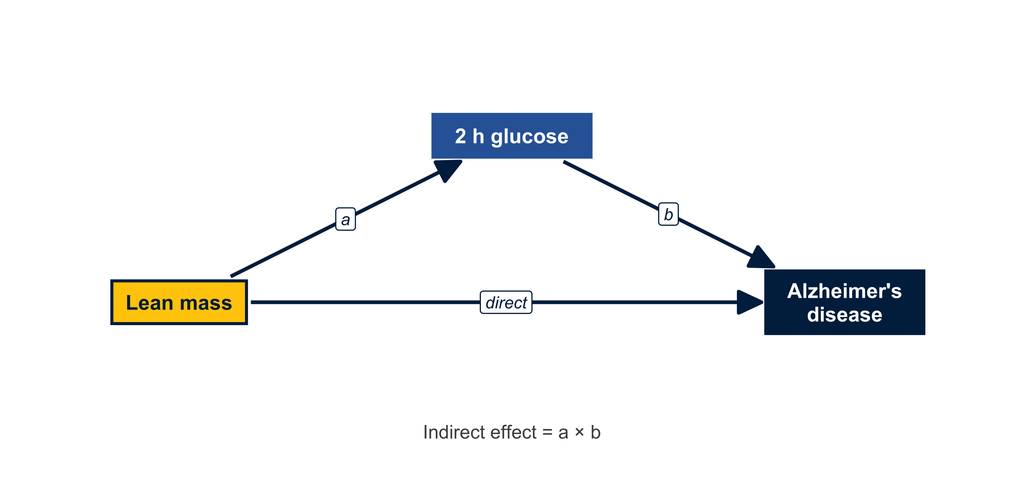

```r
n4 <- bind_rows(
  node("X", "Lean mass", 0, 0, "exposure", w = 0.75),
  node("M", "2 h glucose", 3.2, 1.6, "mediator", w = 0.85),
  node("Y", "Alzheimer's\ndisease", 6.4, 0, "outcome", w = 0.8, h = 0.42))
e4 <- bind_rows(edge("X", "M", label = "a"), edge("M", "Y", label = "b"),
                edge("X", "Y", "question", label = "direct"))
draw_dag(n4, e4, caption = "Indirect effect = a × b", xlim = c(-1, 7.4), ylim = c(-0.9, 2.4))
```

**With unmeasured confounding.** Observational mediation analysis also needs no unmeasured confounding of the mediator and outcome (U → 2 h glucose and U → AD), which is rarely credible. Mendelian randomization handles it by instrumenting both lean mass and 2 h glucose with genetic variants (multivariable MR), so U is bypassed on both legs, subject to the same three assumptions.

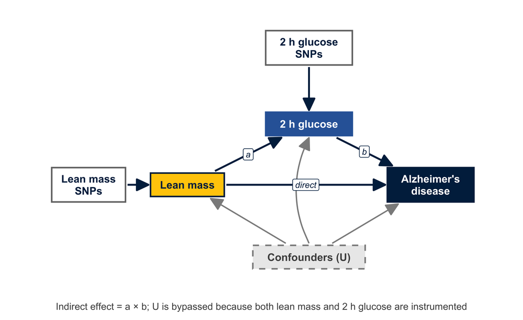

```r
n4u <- bind_rows(n4, node("U", "Confounders (U)", 3.2, -1.9, "confounder", w = 0.95),
                 node("GX", "Lean mass\nSNPs", -2.6, 0, "instrument", w = 0.65, h = 0.42),
                 node("GM", "2 h glucose\nSNPs", 3.2, 3.6, "instrument", w = 0.7, h = 0.42))
e4u <- bind_rows(e4, edge("GX", "X"), edge("GM", "M"),
                 edge("U", "X", "confound"), edge("U", "M", "confound", curvature = -0.25),
                 edge("U", "Y", "confound"))
draw_dag(n4u, e4u, caption = "Indirect effect = a × b; U is bypassed because both lean mass and 2 h glucose are instrumented",
         xlim = c(-3.5, 7.4), ylim = c(-2.6, 4.3))
```

## 5. The overall model

Lean mass protects against AD; part of that may run through lower peak (2 h post-load) glucose. Each leg is instrumented, so unmeasured confounding (U) is bypassed. Survival bias is handled by correcting the AD associations for their link with lifespan (SlopeHunter). The 2 h glucose GWAS is adjusted for BMI, which is why the lean mass → glucose leg is still unresolved.

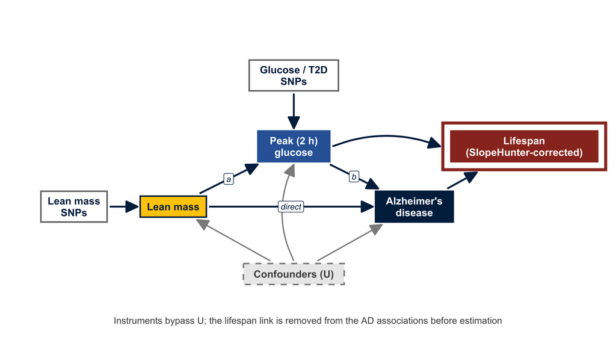

```r
n5 <- bind_rows(
  node("GX", "Lean mass\nSNPs", -2.8, 0, "instrument", w = 0.65, h = 0.42),
  node("X", "Lean mass", 0, 0, "exposure", w = 0.75),
  node("M", "Peak (2 h)\nglucose", 3.4, 1.7, "mediator", w = 0.75, h = 0.42),
  node("GM", "Glucose / T2D\nSNPs", 3.4, 3.7, "instrument", w = 0.85, h = 0.42),
  node("Y", "Alzheimer's\ndisease", 6.8, 0, "outcome", w = 0.8, h = 0.42),
  node("U", "Confounders (U)", 3.4, -1.9, "confounder", w = 0.95),
  node("S", "Lifespan\n(SlopeHunter-corrected)", 9.9, 1.7, "selection", w = 1.15, h = 0.42, boxed = TRUE))
e5 <- bind_rows(
  edge("GX", "X"), edge("GM", "M"),
  edge("X", "M", label = "a"), edge("M", "Y", label = "b"), edge("X", "Y", "question", label = "direct"),
  edge("U", "X", "confound"), edge("U", "M", "confound", curvature = -0.25), edge("U", "Y", "confound"),
  edge("Y", "S"), edge("M", "S", curvature = -0.2))
draw_dag(n5, e5,
         caption = "Instruments bypass U; the lifespan link is removed from the AD associations before estimation",
         xlim = c(-3.7, 11.3), ylim = c(-2.6, 4.4))
```